# Flights analyse

Morad - Fatima - Fred

22 janvier 2020

## Import des modules

```r
library(tidyverse)
library(nycflights13)

data(flights)
flights <- flights

data(weather)
weather <- weather

data(planes)
planes <- planes

data(airports)
airports <- airports

data(airlines)
airlines <- airlines
```

# Premier traitement

**nycflights13** est le package qui nous propose cinq bases de données listant différents paramètres qui interviennent lors des vols au départ de NewYork, tels que :  
- les **conditions climatiques** heure par heure,  
- les **compagnies aériennes**,  
- ou encore les **informations précises sur les différents vols**.

On se rend compte que certaines bases de données ne nous seront pas utiles pour notre études, c’est pourquoi nous nous intéresserons davantage à la bases de données **flights** , **weather** et **airline**.

## I. Base de données *flights*

```r
?nycflights13::flights # Affichage de la définition des variables
```

### 1. Afficher les noms et le type des variables présentes dans **flights**

Nous commençons dans un premier temps par analyser **flights**.  
On souhaite se pencher sur les colonnes « distance », « dep_delay », « arr_delay » et « air_time ».

#### a. Méthode 1 avec fonction lapply() :

```r
c(lapply(flights, mode))
```

```
## $year
## [1] "numeric"
##
## $month
## [1] "numeric"
##
## $day
## [1] "numeric"
##
## $dep_time
## [1] "numeric"
##
## $sched_dep_time
## [1] "numeric"
##
## $dep_delay
## [1] "numeric"
##
## $arr_time
## [1] "numeric"
##
## $sched_arr_time
## [1] "numeric"
##
## $arr_delay
## [1] "numeric"
##
## $carrier
## [1] "character"
##
## $flight
## [1] "numeric"
##
## $tailnum
## [1] "character"
##
## $origin
## [1] "character"
##
## $dest
## [1] "character"
##
## $air_time
## [1] "numeric"
##
## $distance
## [1] "numeric"
##
## $hour
## [1] "numeric"
##
## $minute
## [1] "numeric"
##
## $time_hour
## [1] "numeric"
```

#### b. Méthode 2 avec la fonction str() :

```r
str(flights)
```

```
## Classes 'tbl_df', 'tbl' and 'data.frame':    336776 obs. of  19 variables:
##  $ year          : int  2013 2013 2013 2013 2013 2013 2013 2013 2013 2013 ...
##  $ month         : int  1 1 1 1 1 1 1 1 1 1 ...
##  $ day           : int  1 1 1 1 1 1 1 1 1 1 ...
##  $ dep_time      : int  517 533 542 544 554 554 555 557 557 558 ...
##  $ sched_dep_time: int  515 529 540 545 600 558 600 600 600 600 ...
##  $ dep_delay     : num  2 4 2 -1 -6 -4 -5 -3 -3 -2 ...
##  $ arr_time      : int  830 850 923 1004 812 740 913 709 838 753 ...
##  $ sched_arr_time: int  819 830 850 1022 837 728 854 723 846 745 ...
##  $ arr_delay     : num  11 20 33 -18 -25 12 19 -14 -8 8 ...
##  $ carrier       : chr  "UA" "UA" "AA" "B6" ...
##  $ flight        : int  1545 1714 1141 725 461 1696 507 5708 79 301 ...
##  $ tailnum       : chr  "N14228" "N24211" "N619AA" "N804JB" ...
##  $ origin        : chr  "EWR" "LGA" "JFK" "JFK" ...
##  $ dest          : chr  "IAH" "IAH" "MIA" "BQN" ...
##  $ air_time      : num  227 227 160 183 116 150 158 53 140 138 ...
##  $ distance      : num  1400 1416 1089 1576 762 ...
##  $ hour          : num  5 5 5 5 6 5 6 6 6 6 ...
##  $ minute        : num  15 29 40 45 0 58 0 0 0 0 ...
##  $ time_hour     : POSIXct, format: "2013-01-01 05:00:00" "2013-01-01 05:00:00" ...
```

#### c. Méthode 3 avec une boucle for :

```r
for (i in colnames(flights)){
  print(i)
  print(mode(flights[[i]]))
  print("----------")
}
```

```
## [1] "year"
## [1] "numeric"
## [1] "----------"
## [1] "month"
## [1] "numeric"
## [1] "----------"
## [1] "day"
## [1] "numeric"
## [1] "----------"
## [1] "dep_time"
## [1] "numeric"
## [1] "----------"
## [1] "sched_dep_time"
## [1] "numeric"
## [1] "----------"
```

[output cut: 42 more lines]

### 2. Gestion des valeurs manquantes

On souhaite recupérer les lignes qui ont une valeur manquante dans au moins une des variables citées.

On remarque alors la présence de valeurs manquantes, deux possibilités s’offrent alors a nous :  
- supprimer les lignes contenant des valeurs manquantes  
- remplacer par une d’autres valeurs  
Nous, choisirons de ne pas les prendre en compte dans nos prochains calculs grâce au paramètre “**na.rm =**”.

```r
flights_na <- flights %>% filter(is.na(distance) | is.na(dep_delay) | is.na(arr_delay) | is.na(air_time))
```

On peut supposer que certains vols ont été annulés, notamment les lignes où on retrouve des valeurs nulles à l’heure départ et à l’heure d’arrivée.

On les enregistres

```r
write.table(flights_na, file = "flights_na.csv", sep = ',')
```

### 3. Conversion vers des unités de mesures plus familières

```r
flights_1 <- flights %>%
  mutate(dist_km = distance*1.609,
         kmh=(dist_km/air_time)*60) %>%
  select(time_hour, origin, dest, dep_delay, arr_delay, air_time, dist_km, kmh)
```

### 4. Statistiques

Nous souhaitons à présent observer les données statistiques de nos vols en fonction des aéroports de départ (les valeurs des distances étant en miles nous les avons convertis en kilomètres) :

#### STATS DISTANCE

```r
flights_1 %>%
  group_by(origin) %>%
  summarise(moyenne_distance = mean(dist_km, na.rm = TRUE),
            ecarttype_distance = sd(dist_km, na.rm = TRUE),
            min_distance = min(dist_km, na.rm = TRUE),
            ma_distancex = max(dist_km, na.rm = TRUE))
```

```
## # A tibble: 3 x 5
##   origin moyenne_distance ecarttype_distance min_distance ma_distancex
##   <chr>             <dbl>              <dbl>        <dbl>        <dbl>
## 1 EWR               1700.              1175.         27.4        7985.
## 2 JFK               2037.              1442.        151.         8018.
## 3 LGA               1255.               598.        154.         2607.
```

#### STATS DEP_DELAY

```r
flights_1 %>%
  group_by(origin) %>%
  summarise(moyenne_dep_delay = mean(dep_delay, na.rm = TRUE),
            ecarttype_dep_delay = sd(dep_delay, na.rm = TRUE),
            min_dep_delay = min(dep_delay, na.rm = TRUE),
            max_dep_delay = max(dep_delay, na.rm = TRUE))
```

```
## # A tibble: 3 x 5
##   origin moyenne_dep_delay ecarttype_dep_delay min_dep_delay max_dep_delay
##   <chr>              <dbl>               <dbl>         <dbl>         <dbl>
## 1 EWR                 15.1                41.3           -25          1126
## 2 JFK                 12.1                39.0           -43          1301
## 3 LGA                 10.3                40.0           -33           911
```

#### STATS ARR_DELAY

```r
flights_1 %>%
  group_by(origin) %>%
  summarise(moyenne_arr_delay = mean(arr_delay, na.rm = TRUE),
            ecarttype_arr_delay = sd(arr_delay, na.rm = TRUE),
            min_arr_delay = min(arr_delay, na.rm = TRUE),
            max_arr_delay = max(arr_delay, na.rm = TRUE))
```

```
## # A tibble: 3 x 5
##   origin moyenne_arr_delay ecarttype_arr_delay min_arr_delay max_arr_delay
##   <chr>              <dbl>               <dbl>         <dbl>         <dbl>
## 1 EWR                 9.11                45.5           -86          1109
## 2 JFK                 5.55                44.3           -79          1272
## 3 LGA                 5.78                43.9           -68           915
```

#### STATS AIR_TIME

```r
flights_1 %>%
  group_by(origin) %>%
  summarise(moyenne_air_time = mean(air_time, na.rm = TRUE), #na.rm ne compte pas les valeurs NULL
            ecarttype_air_time = sd(air_time, na.rm = TRUE),
            min_air_time = min(air_time, na.rm = TRUE),
            max_air_time= max(air_time, na.rm = TRUE))
```

```
## # A tibble: 3 x 5
##   origin moyenne_air_time ecarttype_air_time min_air_time max_air_time
##   <chr>             <dbl>              <dbl>        <dbl>        <dbl>
## 1 EWR                153.               93.3           20          695
## 2 JFK                178.              114.            21          691
## 3 LGA                118.               49.4           21          331
```

On peut alors se questionner sur le **lien entre la quantité de vols proposés par l’aéroport et les retards**, ou encore sur l’éventuelle **corrélation entre la distance et les retards** occasionnés.

## II. Base de données *weather*

Sachant que nous avons à notre disposition plusieurs bases de données qui peuvent préciser notre analyse, observons à présent les donnés de la base **weather**…

```r
?nycflights13::weather
```

### 1. Afficher les noms et le type de variable présentes dans **weather**

```r
str(weather)
```

```
## Classes 'tbl_df', 'tbl' and 'data.frame':    26115 obs. of  15 variables:
##  $ origin    : chr  "EWR" "EWR" "EWR" "EWR" ...
##  $ year      : int  2013 2013 2013 2013 2013 2013 2013 2013 2013 2013 ...
##  $ month     : int  1 1 1 1 1 1 1 1 1 1 ...
##  $ day       : int  1 1 1 1 1 1 1 1 1 1 ...
##  $ hour      : int  1 2 3 4 5 6 7 8 9 10 ...
##  $ temp      : num  39 39 39 39.9 39 ...
##  $ dewp      : num  26.1 27 28 28 28 ...
##  $ humid     : num  59.4 61.6 64.4 62.2 64.4 ...
##  $ wind_dir  : num  270 250 240 250 260 240 240 250 260 260 ...
##  $ wind_speed: num  10.36 8.06 11.51 12.66 12.66 ...
##  $ wind_gust : num  NA NA NA NA NA NA NA NA NA NA ...
##  $ precip    : num  0 0 0 0 0 0 0 0 0 0 ...
##  $ pressure  : num  1012 1012 1012 1012 1012 ...
##  $ visib     : num  10 10 10 10 10 10 10 10 10 10 ...
##  $ time_hour : POSIXct, format: "2013-01-01 01:00:00" "2013-01-01 02:00:00" ...
```

### 2. Gestion des valeurs manquantes

De la même manière que pour la base de données **flights**, nous avons regardé les valeurs manquantes…

```r
weather_na <- weather %>%
  filter(is.na(temp) | is.na(dewp) | is.na(humid) | is.na(wind_speed) | is.na(precip) | is.na(visib))
```

… nous choisissons de ne pas en tenir compte lors des calculs statistiques.

```r
write.table(weather_na, file="weather_na.csv", sep=",")
```

### 3. Conversion vers des unités de mesures plus familières

```r
weather_1 <- weather %>%
  mutate(temp_celsius = (temp-32)/1.8,
         lim_rosee = (dewp-32)/1.8,
         rosee = if_else (temp_celsius<=lim_rosee, TRUE, FALSE),
         vent_kmh = wind_speed*1.609,
         rafale_kmh = wind_gust*1.609,
         pluie_cm = precip*2.54,
         visib_km = visib*1.609) %>%
  rename(vent_dir=wind_dir,
         pression=pressure) %>%
  select(origin, time_hour, temp_celsius, lim_rosee, rosee, humid,
         vent_dir, vent_kmh, rafale_kmh, pluie_cm, visib_km, pression)
```

### 4. Statistiques

On souhaite se pencher sur les colonnes «**temps_celsius**», «**vent_kmh**», «**pluie_cm**» et «**visibilité_km**»

```r
nyc_weather <- unique(weather_1$origin)
for (i in nyc_weather){
  print(i)
  a <- weather_1 %>%
    filter(origin==i) %>%
    select(temp_celsius, vent_kmh, pluie_cm, visib_km) %>%
    summary()
  print(a)

  b <- weather_1 %>%
    filter(origin==i) %>%
    summarise(std_temp=sd(temp_celsius, na.rm=TRUE),
              std_vent=sd(vent_kmh, na.rm=TRUE),
              std_pluie=sd(pluie_cm, na.rm=TRUE),
              std_visib=sd(visib_km, na.rm=TRUE))
  print(b)
  print("-------------------------------------------------------------")
}
```

```
## [1] "EWR"
##   temp_celsius       vent_kmh           pluie_cm          visib_km
##  Min.   :-11.70   Min.   :   0.000   Min.   :0.00000   Min.   : 0.1931
##  1st Qu.:  4.40   1st Qu.:   9.258   1st Qu.:0.00000   1st Qu.:16.0900
##  Median : 13.30   Median :  14.813   Median :0.00000   Median :16.0900
##  Mean   : 13.08   Mean   :  15.223   Mean   :0.01281   Mean   :14.9267
##  3rd Qu.: 21.70   3rd Qu.:  20.368   3rd Qu.:0.00000   3rd Qu.:16.0900
##  Max.   : 37.80   Max.   :1686.812   Max.   :3.07340   Max.   :16.0900
##  NA's   :1        NA's   :1
## # A tibble: 1 x 4
##   std_temp std_vent std_pluie std_visib
##      <dbl>    <dbl>     <dbl>     <dbl>
## 1     10.2     19.9    0.0875      3.23
## [1] "-------------------------------------------------------------"
## [1] "JFK"
##   temp_celsius       vent_kmh        pluie_cm          visib_km
##  Min.   :-11.10   Min.   : 0.00   Min.   :0.00000   Min.   : 0.00
##  1st Qu.:  4.40   1st Qu.:11.11   1st Qu.:0.00000   1st Qu.:16.09
##  Median : 12.20   Median :16.66   Median :0.00000   Median :16.09
##  Mean   : 12.48   Mean   :18.45   Mean   :0.01012   Mean   :14.77
##  3rd Qu.: 20.60   3rd Qu.:24.07   3rd Qu.:0.00000   3rd Qu.:16.09
##  Max.   : 36.70   Max.   :68.51   Max.   :1.67640   Max.   :16.09
##                   NA's   :3
## # A tibble: 1 x 4
##   std_temp std_vent std_pluie std_visib
##      <dbl>    <dbl>     <dbl>     <dbl>
## 1     9.48     9.50    0.0659      3.48
## [1] "-------------------------------------------------------------"
## [1] "LGA"
##   temp_celsius      vent_kmh        pluie_cm          visib_km
##  Min.   :-11.1   Min.   : 0.00   Min.   :0.00000   Min.   : 0.00
##  1st Qu.:  4.4   1st Qu.:11.11   1st Qu.:0.00000   1st Qu.:16.09
##  Median : 13.3   Median :16.66   Median :0.00000   Median :16.09
##  Mean   : 13.2   Mean   :17.09   Mean   :0.01113   Mean   :14.98
##  3rd Qu.: 21.7   3rd Qu.:22.22   3rd Qu.:0.00000   3rd Qu.:16.09
##  Max.   : 37.2   Max.   :64.81   Max.   :2.08280   Max.   :16.09
## # A tibble: 1 x 4
##   std_temp std_vent std_pluie std_visib
##      <dbl>    <dbl>     <dbl>     <dbl>
## 1     9.95     8.74    0.0748      3.20
## [1] "-------------------------------------------------------------"
```

On repère une **valeur abérante** et on l’extrait de la base

```r
weather_1 <- weather_1 %>%
  filter(!(vent_kmh > 500))
```

## III. Jointure des tables

```r
joined <- left_join(flights_1, weather_1)
```

On la sauvegarde au format **RDS**

```r
saveRDS(joined, file="joined.rds")
```

# Graphiques

On a cherché à **expliquer les retards** (hypothèses : aéroport / compagnie aérienne / météo)  
- en fonction des aéroports de départs  
- en fonction des compagnies  
- en fonction de la météo

## Retard / Direction du vent

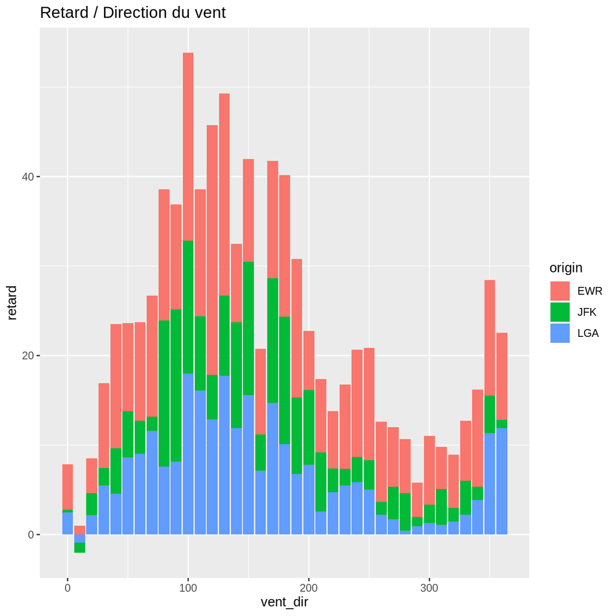

```r
joined %>%
  group_by(origin, vent_dir) %>%
  summarise(retard=mean(arr_delay, na.rm=TRUE)) %>%
  ggplot(aes(x=vent_dir ,y=retard, fill=origin))+
  geom_bar(stat="identity")+
  labs(title="Retard / Direction du vent")
```

## Retard / Force du vent

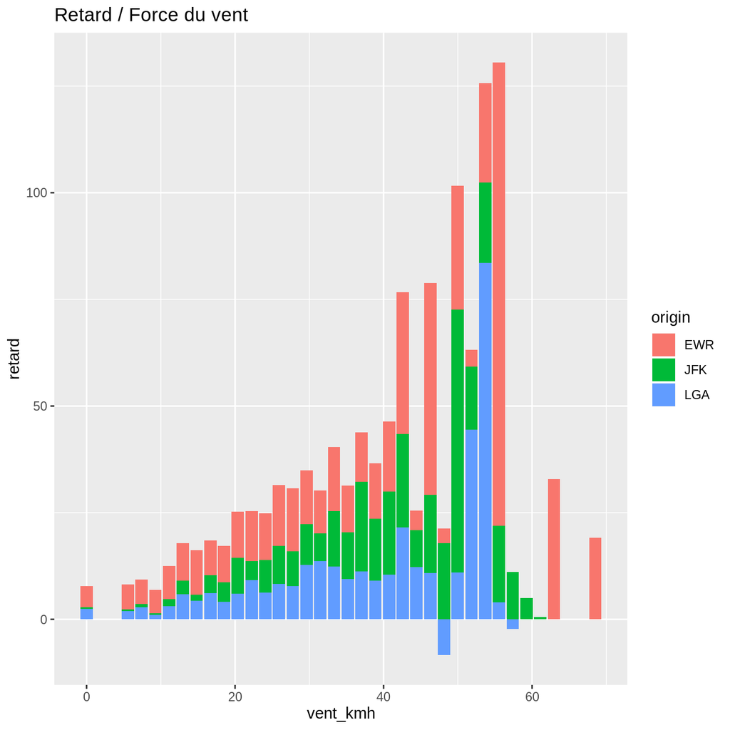

```r
joined %>%
  group_by(origin, vent_kmh) %>%
  summarise(retard=mean(arr_delay, na.rm=TRUE)) %>%
  ggplot(aes(x=vent_kmh ,y=retard, fill=origin))+
  geom_col()+
  labs(title="Retard / Force du vent")
```

On cherche ensuite à mettre en valeur, l’**impact de la puissance de vent sur les retards à l’arrivée**.  
On observe en effet que **plus la vitesse du vent est importante, plus le retard est important**, cependant on observe tout de même une valeur aberrante que nous avons supprimé afin d’obtenir une visualisation graphique.

## Retard / Visibilité

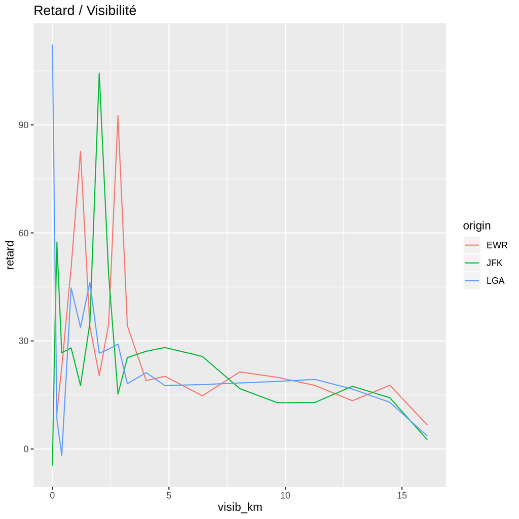

```r
joined %>%
  group_by(origin, visib_km) %>%
  summarise(retard=mean(arr_delay, na.rm=TRUE)) %>%
  ggplot(aes(x=visib_km, y=retard, color=origin))+
  geom_line()+
  labs(title="Retard / Visibilité")
```

A présent, on tente d’observer la **corrélation qui lie la visibilité aux retards des vols**.  
Et on peut supposer qu’**à partir d’environ 4km, la visibilité n’influe pas sur les retards** des vols.  
En effet, **le nombre de minutes de retard est très élevé avant ce seuil** ( plus de 90 min pour les vols en provenance de LGA).

## Vitesse de vol / Direction du vent

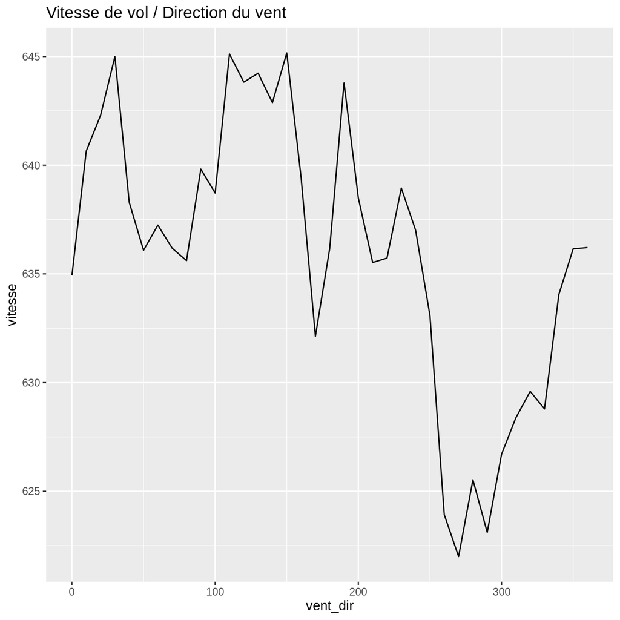

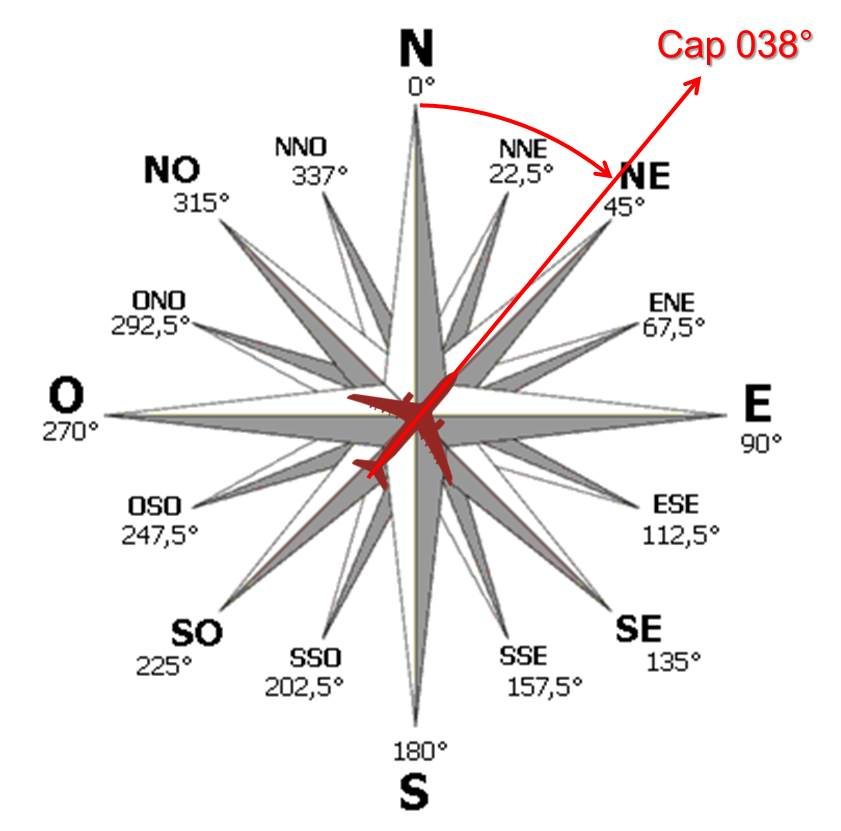

Rose des caps

```r
joined %>%
  group_by(vent_dir) %>%
  summarise(vitesse=mean(kmh, na.rm=TRUE)) %>%
  ggplot(aes(x=vent_dir ,y=vitesse))+
  geom_line()+
  labs(title="Vitesse de vol / Direction du vent")
```

## Retard / Compagnie aérienne

```r
vols_par_compagny <- group_by(flights, carrier)
retard_par_compagny  <- summarize(vols_par_compagny,
                                moyenne_retard = mean(dep_delay, na.rm = TRUE))
table_retard <- left_join(retard_par_compagny, airlines, by = "carrier")
table_retard<-table_retard[,c(1,3,2)]
```

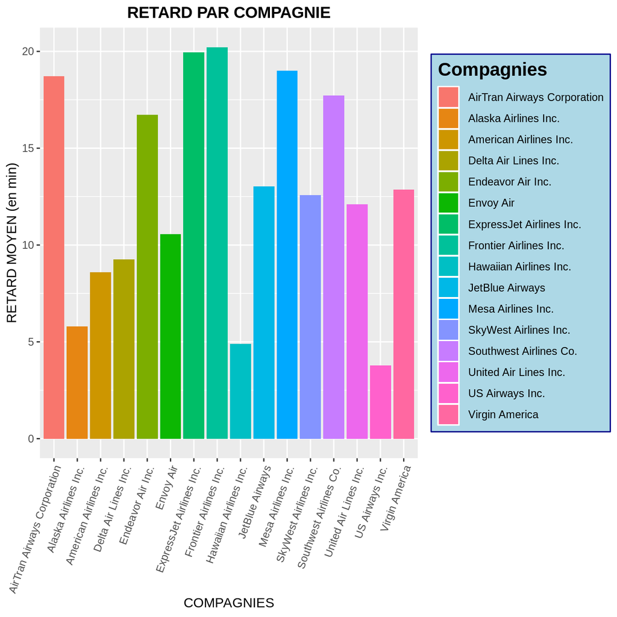

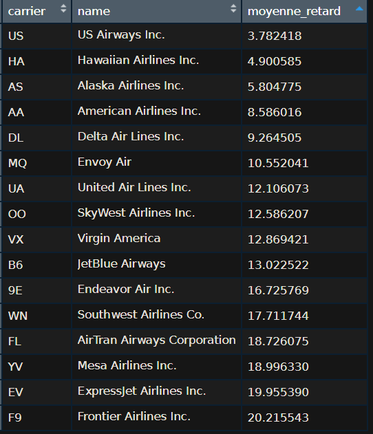

Retard des compagnies aériennes

```r
ggplot(table_retard, aes(name, moyenne_retard, fill = name)) %>%
+ labs(title = "RETARD PAR COMPAGNIE", fill = "Compagnies") %>%
+ theme(plot.title = element_text(face = "bold", hjust = 0.5)) %>%
+ xlab("COMPAGNIES") %>%
+ theme(axis.text.x = element_text(angle = 70, hjust = 1)) %>%
+ ylab("RETARD MOYEN (en min)") %>%
+ theme(legend.title = element_text(colour="black", size=15, face="bold")) %>%
+ theme(legend.background = element_rect(fill="lightblue", size=0.5, linetype="solid", colour ="darkblue")) %>%
+ geom_bar(stat = 'identity')
```

Nous avons comparé la note globale des compagnies aériennes (source:esky) avec notre tableau : il en ressort que les **compagnies qui ont la meilleure note client sont celles qui ont le moins de retard** (même si la note est basée sur plusieurs parametres(confort,qualité de services…).  
On en déduit que **la « qualité » des compagnies aériennes influe sur le retard**.